# Explore weather trends

## Explore Weather Trends

### Contents

#### 1. Target of this Project

#### 2. Extract the data

#### 3. Temperature data analysis

##### 3.1Explore data and plots

#### 4. Moving average and plots

##### 4.1 Moving average data compare plots

#### 5. Analysis and Summary

#### 6. Reference

### Target of this Project

In this project,I will analyze San Francisco where I live temperature data and global temperature and compare the temperature trends of them.

### Extract the data

- Write a SQL query to extract the city level data. Export to CSV.

  ```
  SELECT *
  FROM city_data
  WHERE city = 'San Francisco'
  ;
  ```

- Write a SQL query to extract the global data. Export to CSV.

  ```
  SELECT *
  FROM global_data
  ;
  ```

### Temperature data analysis

Use python data analyze model "pandas" to analysis and loading csv file.

```python
import numpy as np
import pandas as pd
import matplotlib.pyplot as plt
```

### Explore data and plots

From data set global average temperature data start at 1750 and end of 2015,most of average temperature not over 10 degrees celsius.From my live city of San Francisco temperature data set start at 1849 and end of 2013.most of average temperature between 14 - 16 degree celsius.

```python
# Global temperature average data set
global_data = pd.read_csv('global_results.csv')

# San Francisco temperture average data set
sf_data = pd.read_csv('sanfrancisco_results.csv')
```

```python
global_data.head()
```

|  | year | avg_temp |
| --- | --- | --- |
| 0 | 1750 | 8.72 |
| 1 | 1751 | 7.98 |
| 2 | 1752 | 5.78 |
| 3 | 1753 | 8.39 |
| 4 | 1754 | 8.47 |

```python
global_data.tail(3)
```

|  | year | avg_temp |
| --- | --- | --- |
| 263 | 2013 | 9.61 |
| 264 | 2014 | 9.57 |
| 265 | 2015 | 9.83 |

```python
global_data.info()
```

```
<class 'pandas.core.frame.DataFrame'>
RangeIndex: 266 entries, 0 to 265
Data columns (total 2 columns):
year        266 non-null int64
avg_temp    266 non-null float64
dtypes: float64(1), int64(1)
memory usage: 4.2 KB
```

```python
global_data['avg_temp'].describe()
```

```
count    266.000000
mean       8.369474
std        0.584747
min        5.780000
25%        8.082500
50%        8.375000
75%        8.707500
max        9.830000
Name: avg_temp, dtype: float64
```

```python
sf_data.head(3)
```

|  | year | city | country | avg_temp |
| --- | --- | --- | --- | --- |
| 0 | 1849 | San Francisco | United States | 14.12 |
| 1 | 1850 | San Francisco | United States | 13.80 |
| 2 | 1851 | San Francisco | United States | 14.39 |

```python
sf_data.tail(3)
```

|  | year | city | country | avg_temp |
| --- | --- | --- | --- | --- |
| 162 | 2011 | San Francisco | United States | 14.50 |
| 163 | 2012 | San Francisco | United States | 15.05 |
| 164 | 2013 | San Francisco | United States | 16.23 |

```python
sf_data.info()
```

```
<class 'pandas.core.frame.DataFrame'>
RangeIndex: 165 entries, 0 to 164
Data columns (total 4 columns):
year        165 non-null int64
city        165 non-null object
country     165 non-null object
avg_temp    165 non-null float64
dtypes: float64(1), int64(1), object(2)
memory usage: 5.2+ KB
```

```python
sf_data['avg_temp'].describe()
```

```
count    165.000000
mean      14.450788
std        0.504885
min       13.220000
25%       14.120000
50%       14.390000
75%       14.760000
max       16.230000
Name: avg_temp, dtype: float64
```

### Plots

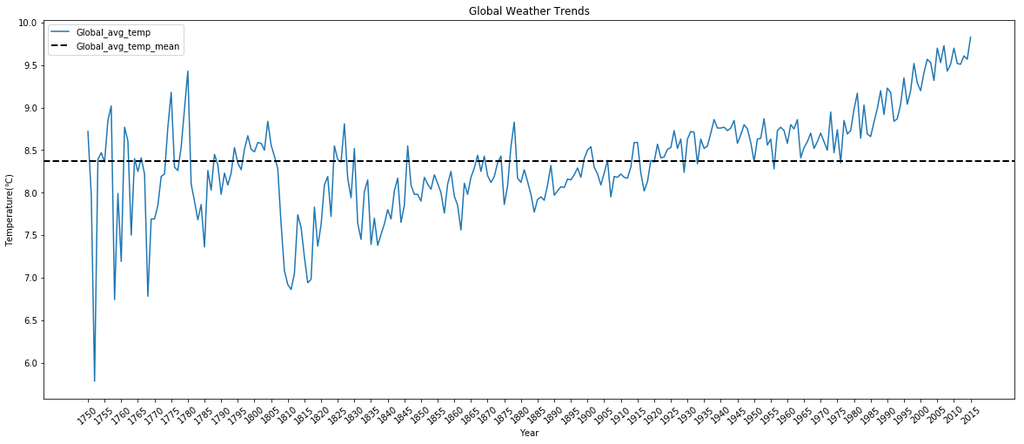

```python
plt.figure(figsize=(20,8))
plt.plot(global_data.year, global_data.avg_temp,label='Global_avg_temp')
plt.axhline(global_data.avg_temp.mean(), color='k', linestyle='dashed', linewidth=2,label='Global_avg_temp_mean')
plt.legend()
plt.xlabel('Year')
plt.ylabel('Temperature(℃)')
plt.title('Global Weather Trends')
plt.xticks(np.arange(1750, 2016, step=5), rotation=40)
plt.show()
```

From global average temperature trends fold line,as we can see the global temperature on the up trend.

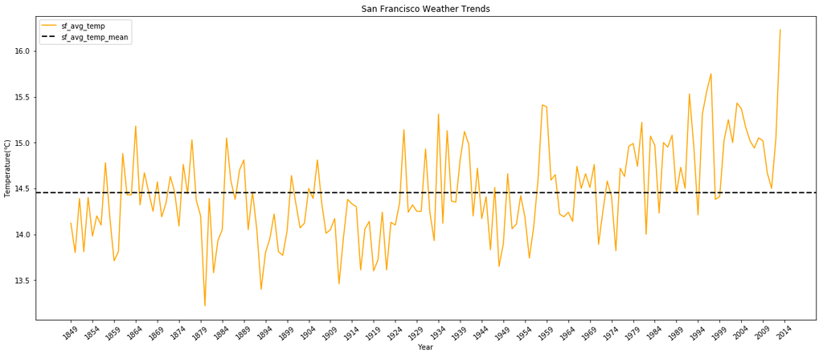

```python
plt.figure(figsize=(20,8))
plt.plot(sf_data.year, sf_data.avg_temp,color='orange',label='sf_avg_temp')
plt.axhline(sf_data.avg_temp.mean(), color='k', linestyle='dashed', linewidth=2,label='sf_avg_temp_mean')
plt.legend()
plt.xlabel('Year')
plt.ylabel('Temperature(℃)')
plt.title('San Francisco Weather Trends')
plt.xticks(np.arange(1849, 2016, step=5), rotation=40)
plt.show()
```

To observation San Francisco average temperature trends,the temperature looks not too much rising trends.it's worth to analyze the trough temperature average and peak temperature average or maybe to find some interesting values in temperature moving average data set.

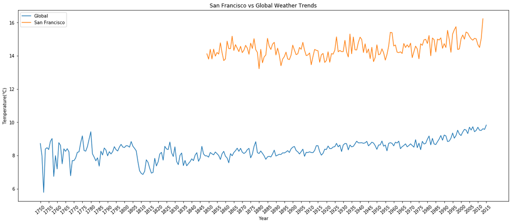

```python
# San Francisco average temperature compare with global average temperaure

plt.figure(figsize=(20,8))
plt.plot(global_data.year, global_data.avg_temp, label='Global')
plt.plot(sf_data.year, sf_data.avg_temp, label='San Francisco')
plt.legend()
plt.title('San Francisco vs Global Weather Trends')
plt.xlabel('Year')
plt.ylabel('Temperature(℃)')
plt.xticks(np.arange(1750, 2016, step=5), rotation=40)
plt.show()
```

To observation San francisco and global weather trends fold lines,it's hard to anaylze weather trends.Because of the fold line fluctuates by years,with moving temperature could be solve the problem.

### Moving average and plots

Setting temperature moving average of 5 years,7years and 10 years then saving into "global_data" and "sf_data"

```python
n = 5
global_data['moving_avg5'] = global_data['avg_temp'].rolling(window=n).mean()
sf_data['moving_avg5'] = sf_data['avg_temp'].rolling(window=n).mean()

n = 7
global_data['moving_avg7'] = global_data['avg_temp'].rolling(window=n).mean()
sf_data['moving_avg7'] = sf_data['avg_temp'].rolling(window=n).mean()

n = 10
global_data['moving_avg10'] = global_data['avg_temp'].rolling(window=n).mean()
sf_data['moving_avg10'] = sf_data['avg_temp'].rolling(window=n).mean()
```

```python
global_data.head(10)
```

|  | year | avg_temp | moving_avg5 | moving_avg7 | moving_avg10 |
| --- | --- | --- | --- | --- | --- |
| 0 | 1750 | 8.72 | NaN | NaN | NaN |
| 1 | 1751 | 7.98 | NaN | NaN | NaN |
| 2 | 1752 | 5.78 | NaN | NaN | NaN |
| 3 | 1753 | 8.39 | NaN | NaN | NaN |
| 4 | 1754 | 8.47 | 7.868 | NaN | NaN |
| 5 | 1755 | 8.36 | 7.796 | NaN | NaN |
| 6 | 1756 | 8.85 | 7.970 | 8.078571 | NaN |
| 7 | 1757 | 9.02 | 8.618 | 8.121429 | NaN |
| 8 | 1758 | 6.74 | 8.288 | 7.944286 | NaN |
| 9 | 1759 | 7.99 | 8.192 | 8.260000 | 8.03 |

```python
sf_data.head(10)
```

|  | year | city | country | avg_temp | moving_avg5 | moving_avg7 | moving_avg10 |
| --- | --- | --- | --- | --- | --- | --- | --- |
| 0 | 1849 | San Francisco | United States | 14.12 | NaN | NaN | NaN |
| 1 | 1850 | San Francisco | United States | 13.80 | NaN | NaN | NaN |
| 2 | 1851 | San Francisco | United States | 14.39 | NaN | NaN | NaN |
| 3 | 1852 | San Francisco | United States | 13.81 | NaN | NaN | NaN |
| 4 | 1853 | San Francisco | United States | 14.40 | 14.104 | NaN | NaN |
| 5 | 1854 | San Francisco | United States | 13.98 | 14.076 | NaN | NaN |
| 6 | 1855 | San Francisco | United States | 14.20 | 14.156 | 14.100000 | NaN |
| 7 | 1856 | San Francisco | United States | 14.10 | 14.098 | 14.097143 | NaN |
| 8 | 1857 | San Francisco | United States | 14.78 | 14.292 | 14.237143 | NaN |
| 9 | 1858 | San Francisco | United States | 14.19 | 14.250 | 14.208571 | 14.177 |

### Plots

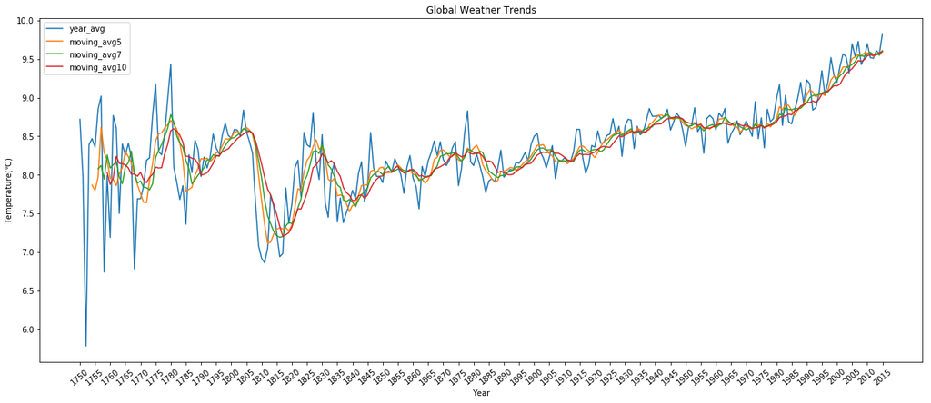

```python
plt.figure(figsize=(20,8))
plt.plot(global_data.year, global_data.avg_temp, label='year_avg')
plt.plot(global_data.year, global_data.moving_avg5, label='moving_avg5')
plt.plot(global_data.year, global_data.moving_avg7, label='moving_avg7')
plt.plot(global_data.year, global_data.moving_avg10, label='moving_avg10')
plt.legend()

plt.title('Global Weather Trends')
plt.xlabel('Year')
plt.xticks(np.arange(1750, 2016, step=5), rotation=40)
plt.ylabel('Temperature(℃)')
plt.show()
```

From 5 years,7years and 10 years global moving average.those fold lines are more clearly to understand the average temperature trends.

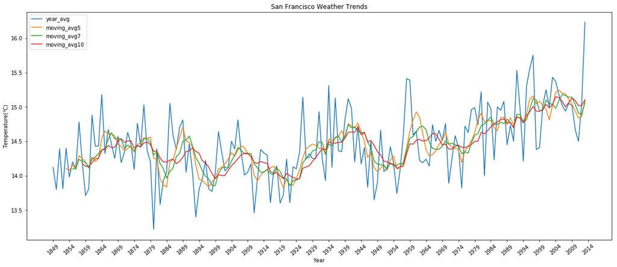

```python
plt.figure(figsize=(20,8))
plt.plot(sf_data.year, sf_data.avg_temp, label='year_avg')
plt.plot(sf_data.year, sf_data.moving_avg5, label='moving_avg5')
plt.plot(sf_data.year, sf_data.moving_avg7, label='moving_avg7')
plt.plot(sf_data.year, sf_data.moving_avg10, label='moving_avg10')
plt.legend()
plt.title('San Francisco Weather Trends')
plt.xlabel('Year')
plt.xticks(np.arange(1849, 2016, step=5), rotation=40)
plt.ylabel('Temperature(℃)')
plt.show()
```

Compared with San Francisco year temperature average and moving average fold lines,moving average fold lines are obviously much understanding than year average.Next,Let's pick up 10 years moving average to find the weather tends.

### Moving average data compare plots

```python
global_data2 = global_data[global_data.year >= 1849]
```

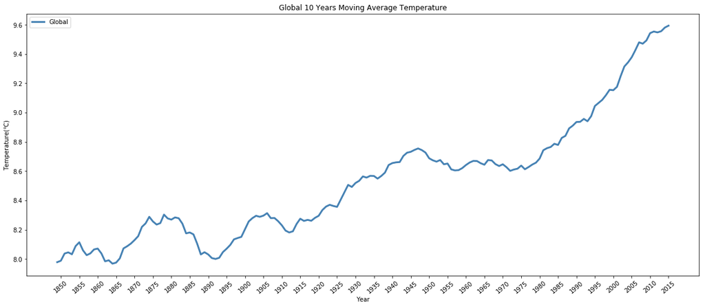

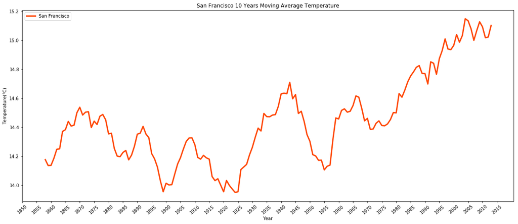

```python
# global 10 years moving average temperature
plt.figure(figsize=(20,8))
plt.plot(global_data2.year, global_data2.moving_avg10, label='Global', color='steelblue', linewidth=3)
plt.title('Global 10 Years Moving Average Temperature')
plt.xlabel('Year')
plt.ylabel('Temperature(℃)')
plt.xticks(np.arange(1850, 2016, step=5), rotation=40)
plt.legend()
plt.show()

# San Francisco 10 years moving average temperature
plt.figure(figsize=(20,8))
plt.plot(sf_data.year, sf_data.moving_avg10, label='San Francisco', color='orangered', linewidth=3)
plt.title('San Francisco 10 Years Moving Average Temperature')
plt.xlabel('Year')
plt.ylabel('Temperature(℃)')
plt.xticks(np.arange(1850, 2016, step=5), rotation=40)
plt.legend()
plt.show()
```

```python
global_data2['moving_avg10'].describe()
```

```
count    167.000000
mean       8.525617
std        0.414640
min        7.968000
25%        8.199000
50%        8.549000
75%        8.696000
max        9.594000
Name: moving_avg10, dtype: float64
```

```python
sf_data['moving_avg10'].describe()
```

```
count    156.000000
mean      14.440968
std        0.301796
min       13.951000
25%       14.201750
50%       14.413000
75%       14.607000
max       15.148000
Name: moving_avg10, dtype: float64
```

Combine with global 10 years moving average and San Francisco 10 years moving average fold lines together.

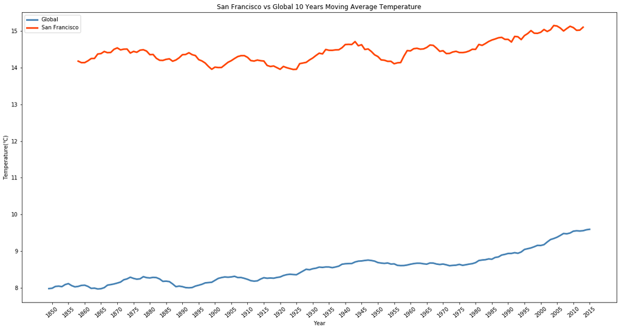

```python
# san francisco vs global moving average temperture
plt.figure(figsize=(20,10))
plt.plot(global_data2.year, global_data2.moving_avg10, label='Global', color='steelblue', linewidth=3)
plt.plot(sf_data.year, sf_data.moving_avg10, label='San Francisco', color='orangered', linewidth=3)
plt.legend()
plt.title('San Francisco vs Global 10 Years Moving Average Temperature')
plt.xlabel('Year')
plt.ylabel('Temperature(℃)')
plt.xticks(np.arange(1850, 2016, step=5), rotation=40)
plt.show()
```

### Analysis and Summary

#### 3.What does the overall trend look like? Is the world getting hotter or cooler? Has the trend been consistent over the last few hundred years?

To observation the whole weather trends the world is getting hotter and San Francisco as well,experically in last few hundred years.from san francisco 10 years moving average plot is clearly to shows start from 1925 the temperature has highly rising up after that year the temperature has come down,from 1955 the temperature has steadily growth the peak temperature is 15.14 clesius.the gobal temperature steadily growth from 1975 the peak 10 years moving average temperature is 9.59 clesius.

In conclusion,from the fold lines have same up-trend that can be predict global and San francisco temperature will continue to raising up.Is that will effect on global ecosystem or human living actuality? That will have more research to determine it.

### Reference

1. [Pandas moving average](http://pandas.pydata.org/pandas-docs/version/0.17.0/generated/pandas.rolling_mean.html)
2. [San Francisco Climate](https://en.wikipedia.org/wiki/San_Francisco#Climate)